# High_Dimension_Data

In this example we'll work with the ["Iris" dataset](https://en.wikipedia.org/wiki/Iris_flower_data_set) which contains four dimensions of measurements on the three types of iris flower species.

```python
import matplotlib.pyplot as plt
import pandas as pd
import seaborn as sns
import numpy as np
import scipy.stats as ss

sns.set_style('white')

%matplotlib inline
```

This dataset is also included in seaborn, so we can load it this way.

```python
iris = sns.load_dataset('iris')
iris.head()
```

|  | sepal_length | sepal_width | petal_length | petal_width | species |
| --- | --- | --- | --- | --- | --- |
| 0 | 5.1 | 3.5 | 1.4 | 0.2 | setosa |
| 1 | 4.9 | 3.0 | 1.4 | 0.2 | setosa |
| 2 | 4.7 | 3.2 | 1.3 | 0.2 | setosa |
| 3 | 4.6 | 3.1 | 1.5 | 0.2 | setosa |
| 4 | 5.0 | 3.6 | 1.4 | 0.2 | setosa |

We get four dimensions (sepal_length, sepal_width, petal_length, petal_width). One direct way to visualize them is to have a scatter plot for each pair of dimensions. We can use the [**`pairplot()`**](http://stanford.edu/~mwaskom/software/seaborn/generated/seaborn.pairplot.html) function in seaborn to do this.

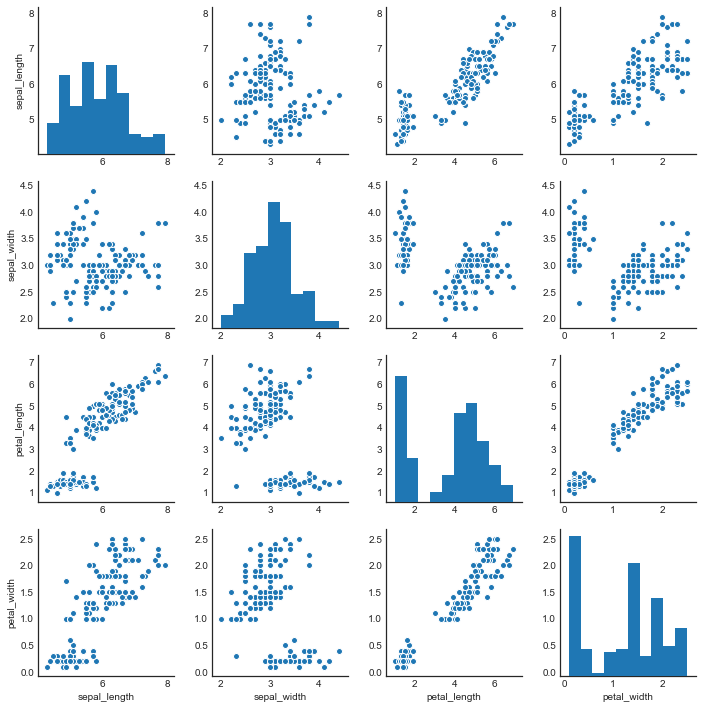

```python
sns.pairplot(iris)
```

We can also color the symbols based on species:

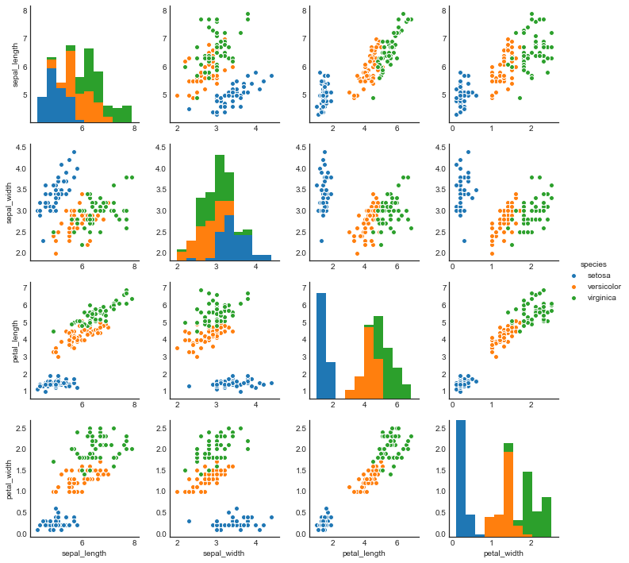

```python
sns.pairplot(iris, hue='species')
```

The colors represent the three different iris species, based on the colors we draw on a scatter plot for a pair of dimensions, we can tell that whether the plot seperates out the species clearly or not.